# Extreme Value Analysis of Potomac River Discharge

Francis Yap

2026-04-28

# 1 Executive Summary

This project applies extreme-value methods to annual maximum daily discharge from the Potomac River at Little Falls. The analysis estimates return levels using Generalized Extreme Value (GEV) and Gumbel models, evaluates uncertainty with profile-likelihood confidence intervals, and studies sampling behavior through parametric and year-resampling simulations.

The workflow is separated into two layers:

The R script contains the computational engine. This R Markdown report loads cached results and presents the analysis.

Heavy simulations are cached as .rds files so that the report can be re-rendered quickly after the first complete run.

# 2 Reproducibility Settings

Main reproducibility settings used in the analysis.

| setting | value |
| --- | --- |
| Random seed | 8010 |
| Return periods for empirical analysis | 5, 10, 15, 20, 25, 30, 35, 40, 45, 50, 55, 60, 65, 70, 75, 80, 85, 90, 95, 100, 105, 110, 115, 120, 125, 130, 135, 140, 145, 150, 155, 160, 165, 170, 175, 180, 185, 190, 195, 200 |
| Simulation record lengths | 30, 50, 75, 95, 150 |
| Simulation return periods | 10, 50, 100 |
| Parametric simulation replicates | 500 |
| Year-resampling replicates | 500 |
| Figure output directory | figures/ |

Load or Run Analysis Objects

The following chunks load cached .rds files when available. If the cache files do not exist, the corresponding workflow is executed and saved for future use.

# 3 Data Overview

Summary of the daily series and annual maxima.

| quantity | value |
| --- | --- |
| Daily observations | 34640 |
| Annual maxima | 95 |
| First year | 1930 |
| Last year | 2024 |
| Minimum annual maximum discharge | 29,100 |
| Median annual maximum discharge | 104,000 |
| Maximum annual maximum discharge | 426,000 |

# 4 Empirical Extreme-Value Analysis

## 4.1 Annual Maxima and Stationarity

The annual maximum series is the basis for the block-maxima extreme-value analysis. A linear smoother is shown as a visual diagnostic, while formal trend evidence is summarized separately using the Mann-Kendall test and a stationary versus nonstationary GEV likelihood-ratio comparison.

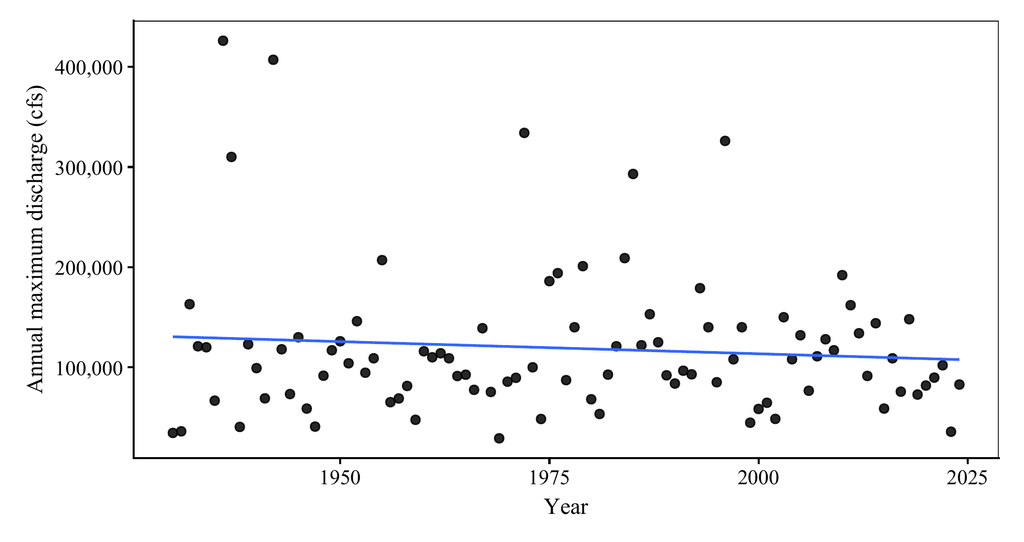

Mann-Kendall trend-test summary.

| test | null_hypothesis | alternative | p_value |
| --- | --- | --- | --- |
| Mann–Kendall trend test | No monotone trend in annual maxima | Monotone trend in annual maxima | 0.9181 |

Stationary versus nonstationary GEV likelihood-ratio summary.

| reduced_model | full_model | logLik_reduced | logLik_full | LRT | df | p_value |
| --- | --- | --- | --- | --- | --- | --- |
| Stationary GEV | Nonstationary GEV with linear trend in location | -1169.991 | -1169.366 | 1.2505 | 1 | 0.2634 |

## 4.2 Model Diagnostic Plot

The Q-Q plot compares empirical annual maxima against fitted model quantiles. Closer agreement with the identity line indicates better distributional fit.

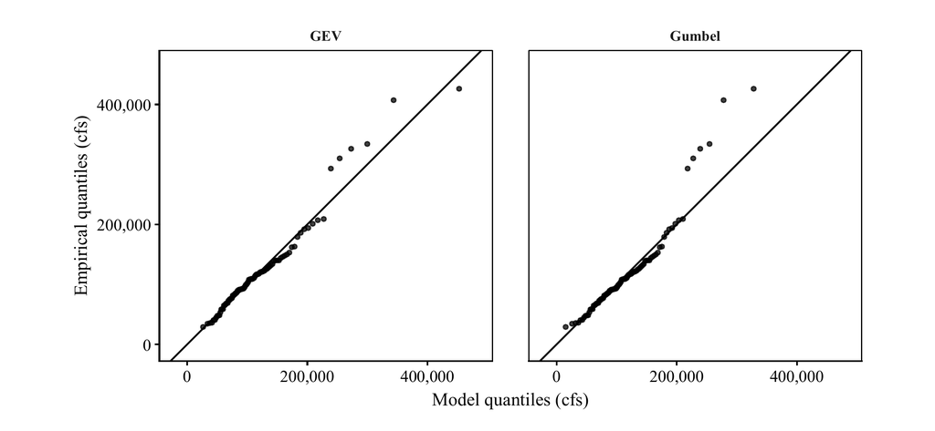

## Return-Level Estimates

Return levels are estimated for both GEV and Gumbel models using profile-likelihood confidence intervals. Uncertainty increases for longer return periods because these estimates require greater extrapolation into the upper tail.

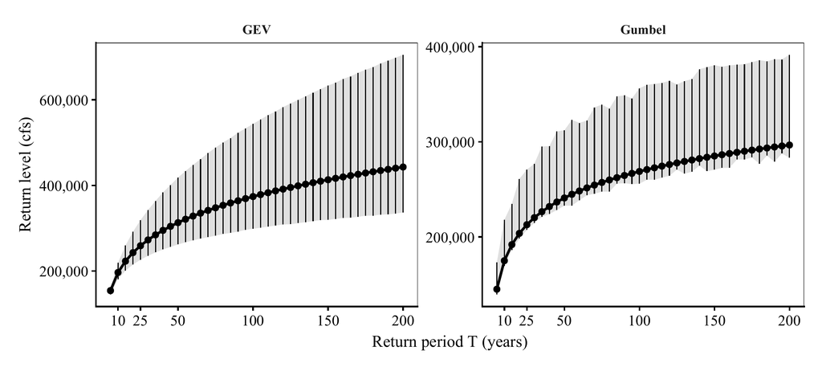

Selected return-level estimates with 95% confidence intervals.

| model | T | RL | CI_low | CI_high |
| --- | --- | --- | --- | --- |
| GEV | 10 | 196,399 | 180,445 | 219,259 |
| GEV | 25 | 258,958 | 226,357 | 318,728 |
| GEV | 50 | 312,942 | 262,090 | 418,166 |
| GEV | 100 | 373,894 | 298,636 | 543,603 |
| GEV | 150 | 413,219 | 319,256 | 633,390 |
| GEV | 200 | 442,923 | 336,679 | 705,248 |
| Gumbel | 10 | 174,962 | 169,286 | 217,887 |
| Gumbel | 25 | 212,830 | 207,235 | 270,686 |
| Gumbel | 50 | 240,922 | 232,833 | 312,094 |
| Gumbel | 100 | 268,807 | 255,920 | 356,181 |
| Gumbel | 150 | 285,068 | 270,612 | 380,534 |
| Gumbel | 200 | 296,590 | 283,206 | 391,482 |

## 4.3 Confidence-Interval Widths

The width of the return-level confidence interval provides a direct summary of estimation uncertainty. Wider intervals at larger return periods reflect the difficulty of estimating rare events from a finite annual-maxima record.

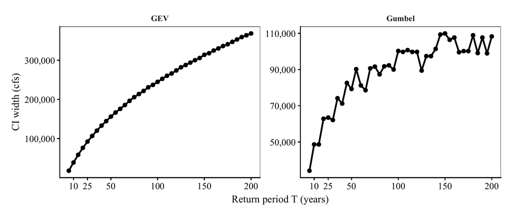

Profile-likelihood confidence interval for the GEV shape parameter.

| Parameter | Estimate | CI_low | CI_high |
| --- | --- | --- | --- |
| xi | 0.1838 | 0.0625 | 0.326 |

## 4.4 Supplementary Empirical Diagnostics

Daily Series and Annual Maxima

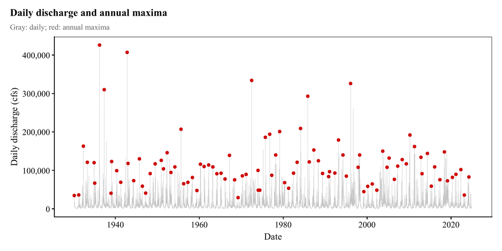

Seasonality of Monthly Maxima

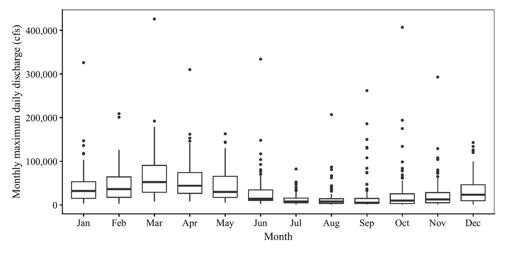

Month of Annual Maximum Occurrence

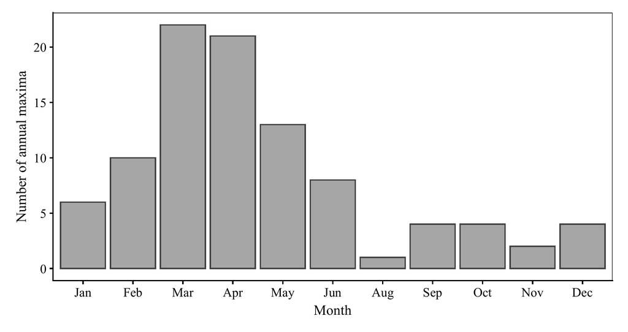

Month-of-occurrence counts for annual maximum discharge.

| month_num | month_lab | n_annual_maxima |
| --- | --- | --- |
| 1 | Jan | 6 |
| 2 | Feb | 10 |
| 3 | Mar | 22 |
| 4 | Apr | 21 |
| 5 | May | 13 |
| 6 | Jun | 8 |
| 8 | Aug | 1 |
| 9 | Sep | 4 |
| 10 | Oct | 4 |
| 11 | Nov | 2 |
| 12 | Dec | 4 |

## 4.5 Parametric Simulation Study

The parametric simulation evaluates how well the GEV estimation workflow recovers known return levels when samples are generated directly from the fitted GEV model. This provides a controlled assessment of bias, RMSE, coverage, and confidence-interval width as record length increases.

Parameter Estimation

Parametric simulation summary for GEV parameter estimates.

| n | bias_mu | rmse_mu | bias_sigma | rmse_sigma | bias_xi | rmse_xi |
| --- | --- | --- | --- | --- | --- | --- |
| 30 | -73.5557 | 7966.860 | -83.2420 | 7291.134 | -0.0057 | 0.1803 |
| 50 | 525.7046 | 6873.938 | -86.2137 | 5603.927 | -0.0054 | 0.1419 |
| 75 | 147.0904 | 5485.847 | 266.7304 | 4685.420 | 0.0012 | 0.1089 |
| 95 | 370.0857 | 4757.433 | 408.1296 | 4222.891 | 0.0017 | 0.0898 |
| 150 | 836.6629 | 3992.065 | 1562.8138 | 3526.457 | -0.0050 | 0.0707 |

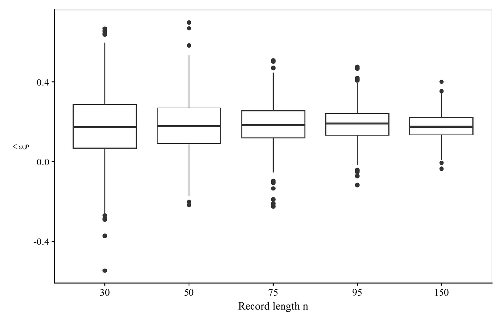

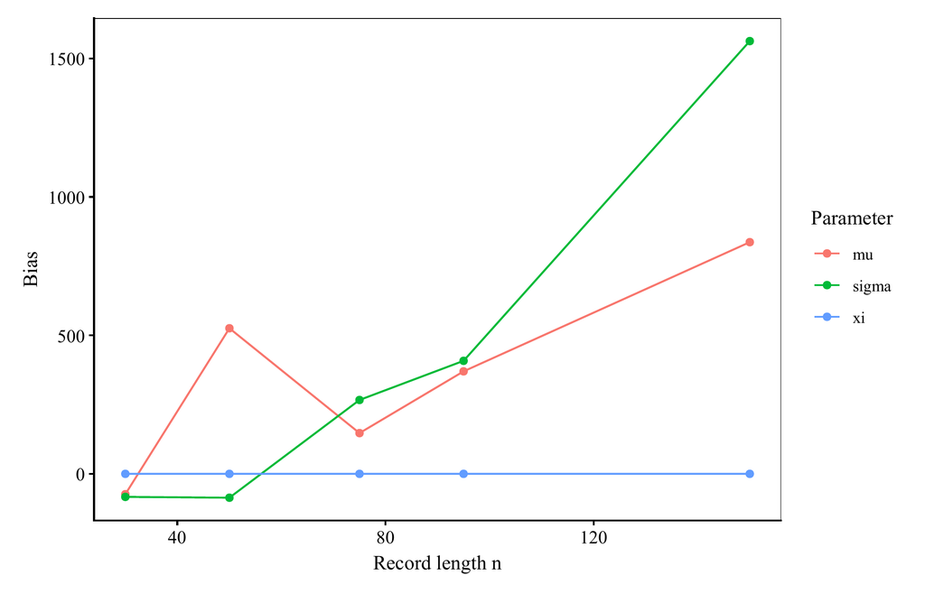

Return-Level Bias and RMSE

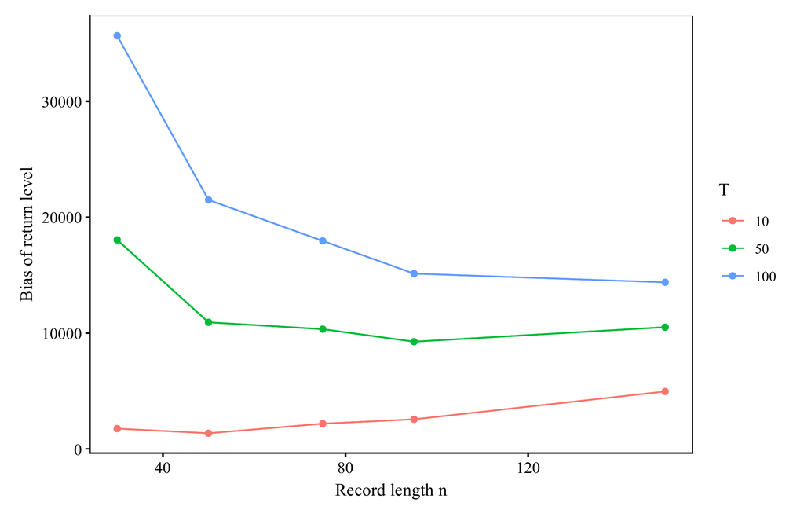

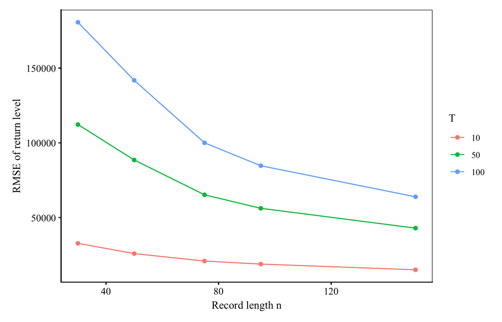

Confidence-Interval Coverage

Coverage is reported conditional on successful confidence-interval fits. This distinction matters because profile-likelihood intervals may occasionally fail for short or unstable simulated samples.

Parametric simulation confidence-interval coverage and mean width.

| n | T | n_used | n_attempted | coverage | mean_width |
| --- | --- | --- | --- | --- | --- |
| 30 | 10 | 499 | 500 | 0.818 | 116,291 |
| 30 | 50 | 499 | 500 | 0.924 | 389,873 |
| 30 | 100 | 499 | 500 | 0.932 | 418,088 |
| 50 | 10 | 499 | 500 | 0.820 | 74,599 |
| 50 | 50 | 499 | 500 | 0.900 | 310,726 |
| 50 | 100 | 499 | 500 | 0.920 | 402,909 |
| 75 | 10 | 488 | 500 | 0.787 | 57,022 |
| 75 | 50 | 488 | 500 | 0.904 | 241,796 |
| 75 | 100 | 488 | 500 | 0.912 | 357,110 |
| 95 | 10 | 481 | 500 | 0.773 | 48,212 |
| 95 | 50 | 481 | 500 | 0.892 | 200,036 |
| 95 | 100 | 481 | 500 | 0.902 | 308,937 |
| 150 | 10 | 311 | 500 | 0.781 | 38,277 |
| 150 | 50 | 311 | 500 | 0.916 | 153,365 |
| 150 | 100 | 311 | 500 | 0.936 | 238,854 |

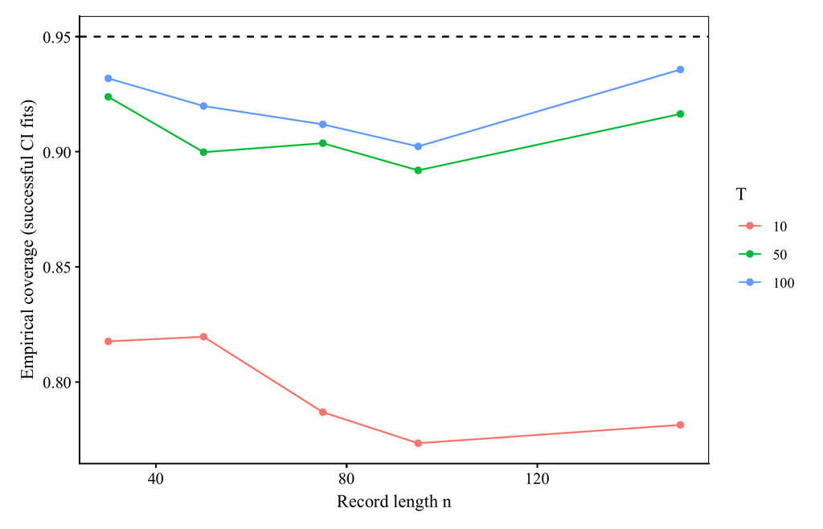

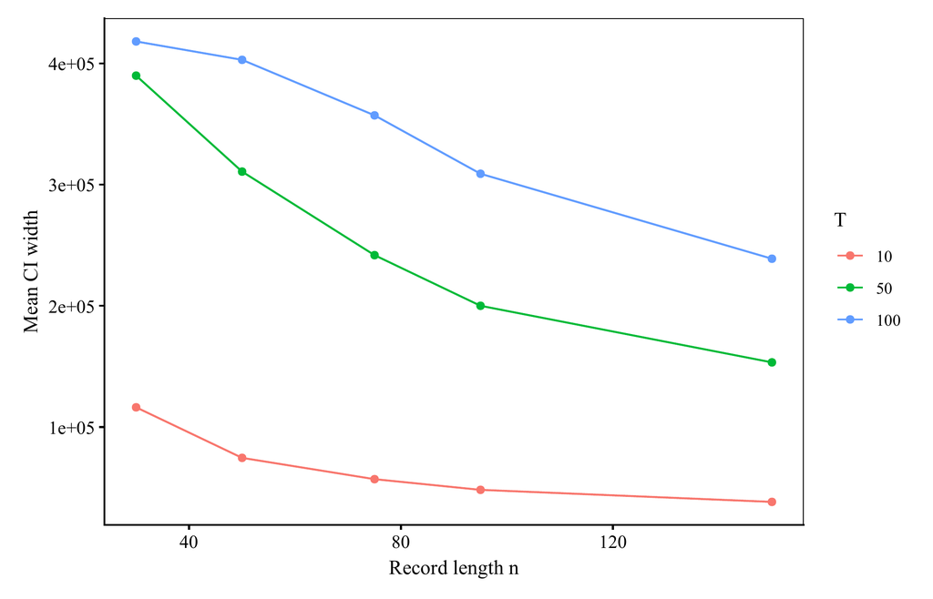

GEV versus Gumbel Simulation Comparison

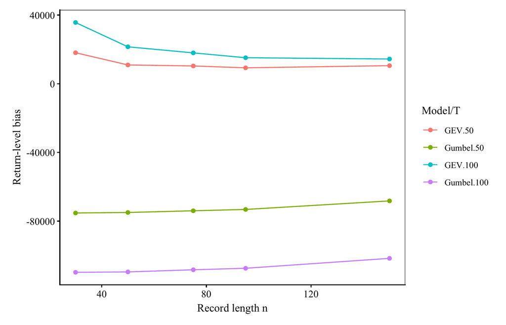

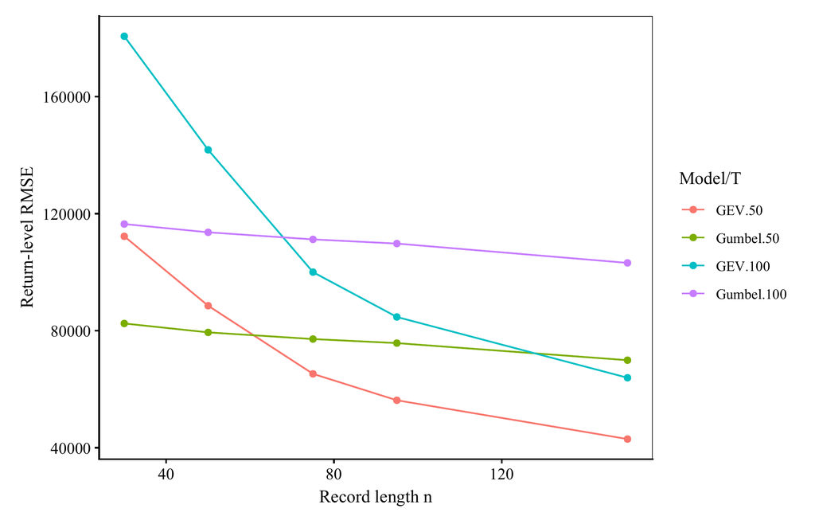

Distribution of Estimated 100-Year Return Levels

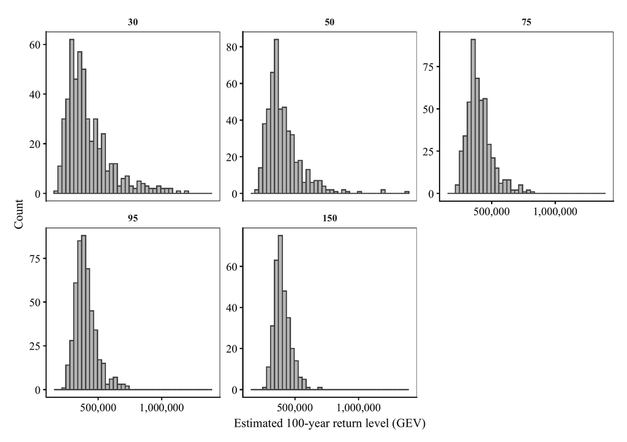

Parametric simulation summary statistics for the estimated 100-year return level.

| n | n_obs | mean | sd | min | q01 | q05 | q10 | q25 | median | q75 | q90 | q95 | q99 | max | iqr |
| --- | --- | --- | --- | --- | --- | --- | --- | --- | --- | --- | --- | --- | --- | --- | --- |
| 30 | 499 | 422035.2 | 177237.93 | 168256.7 | 201321.9 | 229917.8 | 260152.1 | 301606.6 | 374384.7 | 490916.8 | 646225.8 | 824239.6 | 1048500.2 | 1189287.5 | 189310.28 |
| 50 | 499 | 407865.0 | 140305.04 | 186632.8 | 230987.7 | 258715.5 | 273885.0 | 318616.5 | 370268.5 | 460419.9 | 579253.8 | 674895.9 | 897840.1 | 1380474.3 | 141803.37 |
| 75 | 488 | 404332.9 | 98476.22 | 223237.2 | 246750.9 | 275278.9 | 295723.3 | 341987.3 | 386288.0 | 452179.3 | 525976.1 | 595727.6 | 720084.0 | 810986.0 | 110192.02 |
| 95 | 481 | 401508.6 | 83392.30 | 240315.7 | 266566.8 | 293836.2 | 310898.0 | 346030.9 | 388832.9 | 441376.3 | 504976.7 | 553923.0 | 670888.9 | 730083.2 | 95345.38 |
| 150 | 311 | 400759.6 | 62359.04 | 273340.5 | 294164.8 | 318673.4 | 332842.1 | 356341.7 | 392728.0 | 433459.1 | 486782.3 | 513290.3 | 567086.7 | 696298.3 | 77117.44 |

## 4.6 Year-Resampling Robustness Study

The year-resampling experiment resamples full years from the observed daily record, recomputes annual maxima, and refits the GEV model. This assesses how sensitive return-level estimates are to the available historical record.

Reference Inclusion and Interval Width

Year-resampling reference inclusion rates and mean confidence-interval widths.

| n | T | n_used | n_attempted | coverage_reference | mean_width |
| --- | --- | --- | --- | --- | --- |
| 30 | 10 | 499 | 500 | 0.733 | 91,454 |
| 30 | 50 | 499 | 500 | 0.872 | 344,479 |
| 30 | 100 | 499 | 500 | 0.890 | 397,920 |
| 50 | 10 | 500 | 500 | 0.722 | 61,250 |
| 50 | 50 | 500 | 500 | 0.870 | 259,342 |
| 50 | 100 | 500 | 500 | 0.888 | 353,517 |
| 75 | 10 | 498 | 500 | 0.707 | 46,900 |
| 75 | 50 | 498 | 500 | 0.869 | 195,366 |
| 75 | 100 | 498 | 500 | 0.880 | 294,481 |
| 95 | 10 | 498 | 500 | 0.685 | 40,890 |
| 95 | 50 | 498 | 500 | 0.847 | 167,498 |
| 95 | 100 | 498 | 500 | 0.871 | 258,674 |
| 150 | 10 | 463 | 500 | 0.726 | 32,176 |
| 150 | 50 | 463 | 500 | 0.892 | 129,174 |
| 150 | 100 | 463 | 500 | 0.907 | 197,532 |

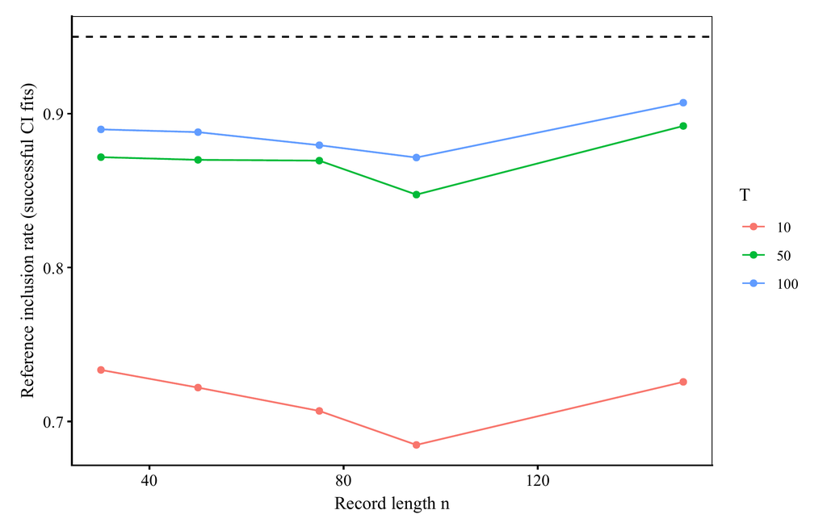

Distribution of Estimated 100-Year Return Levels

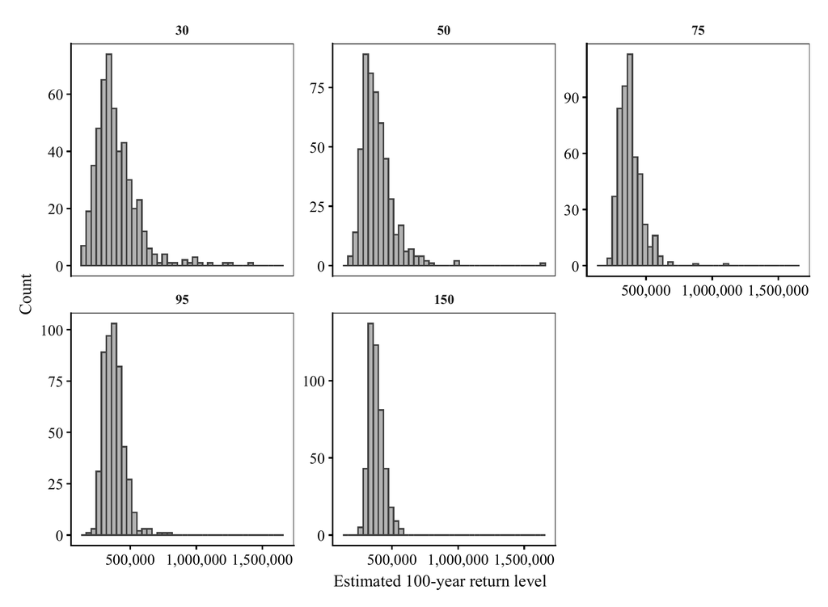

Year-resampling summary statistics for the estimated 100-year return level.

| n | n_obs | mean | sd | min | q01 | q05 | q10 | q25 | median | q75 | q90 | q95 | q99 | max | iqr |
| --- | --- | --- | --- | --- | --- | --- | --- | --- | --- | --- | --- | --- | --- | --- | --- |
| 30 | 499 | 392663.5 | 161344.05 | 147526.0 | 162448.5 | 204523.3 | 229409.9 | 287423.0 | 359215.0 | 455244.7 | 577644.2 | 643562.3 | 998240.2 | 1422775.1 | 167821.71 |
| 50 | 500 | 388142.4 | 124681.41 | 179130.8 | 214956.3 | 251058.7 | 269257.9 | 309332.9 | 363628.8 | 438995.2 | 532631.9 | 603894.2 | 754383.8 | 1641786.1 | 129662.33 |
| 75 | 498 | 379711.2 | 88587.64 | 206180.5 | 249480.3 | 271314.7 | 287247.4 | 319951.9 | 367246.9 | 420469.9 | 476928.6 | 549646.3 | 597777.3 | 1124431.8 | 100518.02 |
| 95 | 498 | 376788.7 | 76933.37 | 202996.2 | 245313.4 | 275313.3 | 291716.5 | 320065.6 | 367930.2 | 418761.4 | 470900.6 | 508908.5 | 627082.7 | 785409.2 | 98695.87 |
| 150 | 463 | 381370.5 | 54509.92 | 257626.0 | 284534.2 | 308957.2 | 319400.4 | 341398.2 | 375029.1 | 411292.0 | 453177.3 | 482549.0 | 532157.4 | 586077.4 | 69893.75 |

## 4.7 Generated Output Files

The following files are the final figures, tables, diagnostics, and cached objects used in this report. Earlier exploratory outputs have been excluded to keep the results concise and reproducible.

Final analysis outputs used in this report.

| file | location |
| --- | --- |
| project_stationarity.png | figures/ |
| project_mann_kendall_summary.csv | figures/ |
| project_stationarity_lrt_summary.csv | figures/ |
| project_qq.png | figures/ |
| project_return_levels_ci.png | figures/ |
| project_return_levels_ci_diagnostics.csv | figures/ |
| project_return_levels_ciwidth.png | figures/ |
| project_xi_profile_ci.csv | figures/ |
| project_daily_series_with_annual_maxima.png | figures/ |
| project_monthly_maxima_seasonality.png | figures/ |
| project_annual_maxima_month_counts.png | figures/ |
| project_annual_maxima_month_counts.csv | figures/ |
| sim_xi_boxplot.png | figures/ |
| sim_param_bias_vs_n.png | figures/ |
| sim_rl_bias_vs_n_mean.png | figures/ |
| sim_rl_rmse_vs_n.png | figures/ |
| sim_ci_summary.csv | figures/ |
| sim_coverage_vs_n.png | figures/ |
| sim_ci_width_vs_n.png | figures/ |
| sim_gumbel_vs_gev_bias_mean.png | figures/ |
| sim_gumbel_vs_gev_rmse_mean.png | figures/ |
| sim_param_rl_distribution_100yr.png | figures/ |
| sim_param_rl100_summary_stats.csv | figures/ |
| resample_ci_summary.csv | figures/ |
| resample_coverage_vs_n.png | figures/ |
| resample_rl_distribution_100yr.png | figures/ |
| sim_resample_rl100_summary_stats.csv | figures/ |
| results_obj.rds | outputs/ |
| sim_param_obj.rds | outputs/ |
| sim_resamp_obj.rds | outputs/ |

All listed files are reproducible from the provided R script and cached objects.